# Survey Data: Domains and Chi-Square Tests

Lecture 10A

PUBHBIO 6250

## What is a “Domain”?

**Domain** = a subgroup in the population that **is not part of the sampling design**

- **Not** a stratum, **not** a cluster/group of clusters
- **Important:** we don’t know what domain a unit belongs to until it is sampled
- Also called subpopulations or subgroups or subclasses

Examples:

- Stratified (by county) random sample of individuals who recently gave birth in Ohio, domain = individuals who did not have a prenatal visit
- Two-stage cluster sample of students within schools, domain = students with a disability

## Domain Sizes (in a sample) are Random

- Number of units in the domain in the sample is a random variable
  - Take another sample, get a **different number of units in the domain**
- Different from a stratum – if we take another sample, guaranteed to get the same number of units in the stratum!
- Variance estimation **must properly account for the survey design**
  - Must have the correct number of PSUs
  - Must have the correct number of strata
- **Cannot simply subset your sample data!**
- Subsetting the data to a domain will cause problems when:
  - A stratum does not contain any members of the domain
  - A PSU does not contain any members of a domain

**One exception:** It’s okay to subset an SRS

## Domain Indicators

- Solution: create an indicator variable, $x_i$, for domain membership

$$x_i = \begin{cases} 1 & \text{unit $i$ is in domain $d$}\\ 0 & \text{unit $i$ not in domain $d$} \end{cases}$$

- Then the estimated domain total in domain $d$ is given by:

$$\hat{t}^{(d)} = \sum_{i \in \mathcal{S}} w_i x_i y_i$$

- And the domain mean would be estimated by:

$$\hat{\bar{y}}^{(d)} = \frac{\sum_{i \in \mathcal{S}} w_i x_i y_i}{\sum_{i \in \mathcal{S}} w_i x_i}$$

## Example: Domain Estimation in NHAMCS

Analysis of data from the 2004 National Hospital Ambulatory Medical Care Survey (West BT, Berglund P, Heeringa SG, 2008)

- 4-stage design with stratification:
  1. PSUs = geographic areas (selection via PPS) (stratified by SES variables)
  2. hospitals within PSUs (selection via PPS)
  3. clinics within hospitals (complex selection procedure involving PPS)
  4. patient visits within clinics (systematic sampling)
- 2004 sample had 8 strata and 294 PSUs (between 6 and 86 PSUs per stratum)

**Domain of interest:** visits to EDs by elderly (age $\ge$ 60) African-American males

**Parameter of interest:** percentage of visits (for this subgroup) with dizziness or vertigo as a reason for the visit

## Example: Domain Estimation in NHAMCS

**Conditional Approach**: Subsetting the data to domain members only (**bad!**)

**Unconditional Approach:** Appropriately including all sampled units (**good!**)

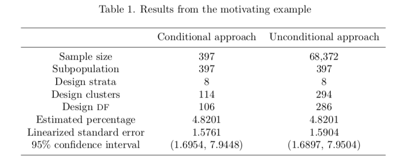

Subsetting results in:

- Wrong number of PSUs, wrong DF, SE too small, CI too narrow
- Identical point estimate (4.8201%) – it’s variability that is wrong

**Special commands in software** necessary to correctly obtain domain estimates

## Comparing Domains with Chi-Square Tests

- Most common type of comparisons = comparing proportions (percentages)
- As with non-survey data (e.g., an SRS), this requires **chi-square tests**
- However, **we must take the survey design into account!**
  - The $X^2$ test statistic **does not have a $\chi^2_{(r-1)(c-1)}$ distribution under the null hypothesis** when complex sampling is used
  - **Ignoring clustering** can **inflate test statistics** and **deflate p-values**
  - **Ignoring stratification** can **deflate test statistics** and **inflate p-values**

The worse crime (usually) is ignoring clustering and “overstating” results (inflating Type 1 error) – but a loss in power is bad too!

## Corrections to Chi-Square Tests

- In an SRS, if $X^2 \sim \chi^2_{(r-1)(c-1)}$, then $E[X^2] = (r-1)(c-1)$

  *(expected value of a chi-square random variable is equal to its DF)*
- With complex sampling designs, $X^2$ from a chi-square test **does not** follow a $\chi^2_{(r-1)(c-1)}$ distribution under $H_0$
- However, can multiply the test statistic $X^2$ by factor(s) in order to make this rescaled test statistic have approximately a $\chi^2$ distribution

Two methods used most often:

- First Order Correction (also called Rao-Scott first order correction)
- Second Order Correction (also called Rao-Scott second order correction)

(not very creatively named)

## Rao-Scott First Order Correction (Chi-Square Test)

- Idea: Match the mean of the test statistic $X^2$ (under the complex design) to the mean of a $\chi^2_{(r-1)(c-1)}$ distribution
- “Rescales” the test statistic to have the “right” distribution under the null
- **First order** – matching the mean
  - Calculate $E[X^2]$ = the expected value of $X^2$ for the complex design under $H_0$
  - Calculate first order corrected test statistic as

  $$X^2_{RS1} = \frac{(r-1)(c-1) X^2}{E[X^2]}$$
  - Compare $X^2_{RS1}$ to a $\chi^2_{(r-1)(c-1)}$ distribution
- In practice, works better to compare $X^2_{RS1}/(r-1)(c-1)$ to an $F$ distribution

## Problem with First Order Correction

- Calculation of $E[X^2]$ depends on the cell and marginal probabilities under the null and the DEFF for estimating each of these probabilities
- Slight problem: we are **only matching the mean of the distribution** – but p-values often come from the tail of the distribution
- Variance of $X^2_{RS1}$ is actually **larger** than variance of $\chi^2_{(r-1)(c-1)}$
  - $\rightarrow$ p-values from $X^2_{RS1}$ are slightly **smaller** than they should be

## Rao-Scott Second Order Correction (Chi-Square Test)

- Idea: Match the mean and variance of the test statistic $X^2$ (under the complex design) to the mean and variance of a $\chi^2_{(r-1)(c-1)}$ distribution
- **Second order** – matching the mean **and** variance
  - Calculate $E[X^2]$ = the expected value of $X^2$ for the complex design under $H_0$
  - Calculate $V[X^2]$ = the variance of $X^2$ under $H_0$
  - Calculate second order corrected test statistic as

  $$X^2_{RS2} =\frac{\nu X^2_{RS1}}{(r-1)(c-1)} \quad \text{where } \nu = 2\frac{(E[X^2])^2}{V[X^2]}$$
  - Compare $X^2_{RS2}$ to a $\chi^2_{\nu}$ distribution
- In practice, works better to compare $X^2_{RS2}/\nu$ to an $F$ distribution

**Many software packages have the second order correction as the default**